# Project 3

Part 1 The MANDATES table has information about when people where elected, when their mandate ended and on which assembly they sat.

Using a line plot, show how the number of people with an active mandate changed over the years. You will have one line per assembly.

```r
# I write down all the libraries I will use
library(dplyr)
library(tidyverse)
library(tidyr)
library(lubridate)
library(httr)
library(purrr)
library(DBI)
library(RSQLite)
library(DBI)
library(janitor)
library(reshape2)
library(ggplot2)
library(ggmap)
# First I import the db file with RSQLite in R Studio and save in a vector each table
Z_politicians <- dbConnect(RSQLite::SQLite(), "zh_politicians.db")
dbListTables(Z_politicians)
```

```
[1] "ADDRESSES"    "AFFILIATIONS" "MANDATES"     "PERSONS"
```

```r
Addresses <- DBI::dbGetQuery(Z_politicians, "SELECT * FROM ADDRESSES;")
```

[output not shown]

```r
Affiliations <- DBI::dbGetQuery(Z_politicians, "SELECT * FROM AFFILIATIONS;")
```

[output not shown]

```r
Mandates <- DBI::dbGetQuery(Z_politicians, "SELECT * FROM MANDATES;")
```

[output not shown]

```r
Persons <- DBI::dbGetQuery(Z_politicians, "SELECT * FROM PERSONS;")
```

```
Column `YEAR_OF_BIRTH`: mixed type, first seen values of type integer, coercing other values of type stringColumn `YEAR_OF_DEATH`: mixed type, first seen values of type string, coercing other values of type integer
```

```r
dbDisconnect(Z_politicians)
# I disconnect from SQL and conver the table Mandates with tibble and clean the table.
Mandates_dates <- as_tibble(rownames_to_column(Mandates, "Politician"))
Mandates_dates1 <- clean_names(Mandates_dates)
# I create a table with the columns I want to plt
Line_plot <- select(Mandates_dates1, 1, 3, 4, 7, 10)
Line_plot
```

| politician | person_id | assembly | mandate_start_year | mandate_end_year |
| --- | --- | --- | --- | --- |
| 1 | 6 | Cantonal Council | 1991 | 1997 |
| 2 | 13 | Cantonal Council | 1975 | 1985 |
| 3 | 28 | Cantonal Council | 1959 | 1971 |
| 4 | 31 | Cantonal Council | 1963 | 1964 |
| 5 | 32 | Cantonal Council | 1955 | 1967 |
| 6 | 38 | Cantonal Council | 1959 | 1963 |
| 7 | 39 | Cantonal Council | 1959 | 1963 |
| 8 | 45 | Cantonal Council | 1943 | 1959 |
| 9 | 46 | Cantonal Council | 1951 | 1958 |
| 10 | 52 | Cantonal Council | 1947 | 1951 |

[output cut: 990 more lines]

```r
# I want to create the chart by a range of time, so I need to know the older and nearest year of the people mandate
aggregate(mandate_start_year ~ assembly, Line_plot, function(x) max(x))
```

| assembly | mandate_start_year |
| --- | --- |
| Cantonal Council | 2018 |
| Executive Council | 2015 |
| Grand Council | 1869 |
| Small Council | 1839 |

```r
aggregate(mandate_start_year ~ assembly, Line_plot, function(x) min(x))
```

| assembly | mandate_start_year |
| --- | --- |
| Cantonal Council | 1838 |
| Executive Council | 1831 |
| Grand Council | 0 |
| Small Council | 1803 |

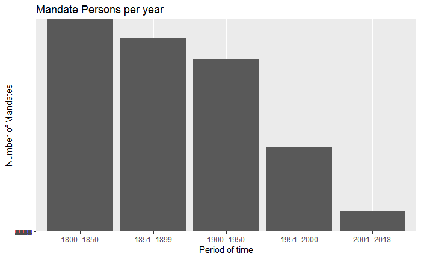

```r
#As I see that there is no date for the mandate_start_date, I will start from 1800
Line_plot %>%
  mutate(mandate_year=case_when(mandate_start_year <= 1850 ~ "1800_1850", mandate_start_year <= 1899 ~ "1851_1899", mandate_start_year <= 1950 ~ "1900_1950", mandate_start_year <= 2000 ~ "1951_2000", TRUE ~ "2001_2018")) %>%
  arrange(mandate_start_year) %>%
  select(mandate_year, politician) %>%
  ggplot(mapping = aes(x= mandate_year, y = politician)) +
  geom_bar(stat="identity") + labs(title="Mandate Persons per year", x="Period of time", y="Number of Mandates")
```

Part 2 Expand on the plot you just produced. This time you want to show a facet charts with one chart per assembly. In each chart, have one line for men and one line for women.

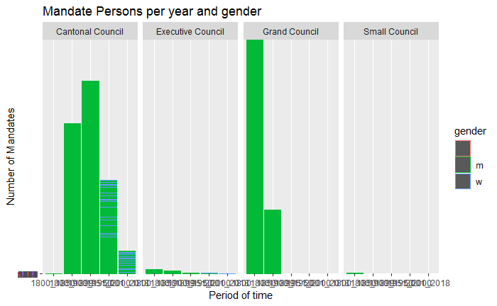

```r
# I take the column Gender in the table Persons to join it with Line_plot
Persons_Assembly <- select(Persons, person_id = ID, gender = GENDER)
Persons_Assembly_chart <- left_join(Persons_Assembly, Line_plot, by= "person_id")
View(Persons_Assembly_chart)
# I start to create the chart by gender
Persons_Assembly_chart %>%
  mutate(mandate_year=case_when(mandate_start_year <= 1850 ~ "1800_1850", mandate_start_year <= 1899 ~ "1800_1899", mandate_start_year <= 1950 ~ "1900_1950", mandate_start_year <= 2000 ~ "1951_2000", TRUE ~ "2001_2018")) %>% arrange(mandate_start_year) %>%
  select(mandate_year, politician, gender, assembly) %>%
  ggplot(mapping = aes(x= mandate_year, y = politician, color = gender, group = assembly)) +
  geom_bar(stat="identity") +
  facet_grid(.~assembly) +
  labs(title="Mandate Persons per year and gender", x="Period of time", y="Number of Mandates")
```

Part 3 Create a new plot showing the proportion of elected politicians from each party in year 2000. You want to show this by assembly, so use one facet with one pie chart per assembly. Also show your result in a table.

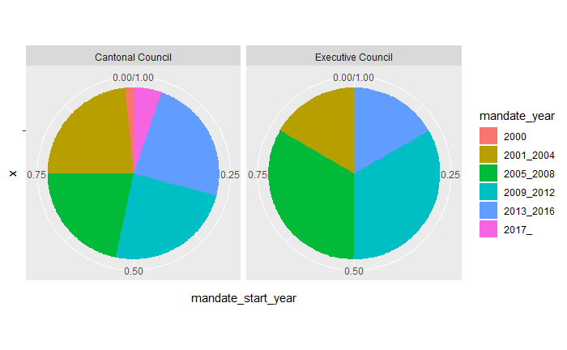

```r
# First I create a table with the number of people elected afer 2000 per assembly to create the pie chart
Table_mandate <- filter(Line_plot, mandate_start_year >=2000)
Table_mandate %>%
  mutate(mandate_year=case_when(mandate_start_year <=2000 ~ "2000", mandate_start_year <= 2004 ~ "2001_2004", mandate_start_year <= 2008 ~ "2005_2008", mandate_start_year <= 2012 ~ "2009_2012", mandate_start_year <= 2016 ~ "2013_2016", TRUE ~"2017_")) %>%
  arrange(mandate_year) %>%
  ggplot(aes(x = "", y = mandate_start_year, fill = mandate_year)) +  geom_bar(stat = "identity", width = 1, position = position_fill()) +    coord_polar(theta = "y") +    facet_wrap( ~ assembly)
```

```r
# Then I create a table with the number of people elected in 2000 per assembly
Table_mandate_2000 <-  filter(Line_plot, mandate_start_year == 2000 )
Table_mandate_2000
```

| politician | person_id | assembly | mandate_start_year | mandate_end_year |
| --- | --- | --- | --- | --- |
| 1877 | 7992 | Cantonal Council | 2000 | 2014 |
| 1977 | 8161 | Cantonal Council | 2000 | 0 |
| 2189 | 8581 | Cantonal Council | 2000 | 2007 |
| 2193 | 8589 | Cantonal Council | 2000 | 2007 |
| 2212 | 8616 | Cantonal Council | 2000 | 2007 |
| 2217 | 8621 | Cantonal Council | 2000 | 2015 |